# EPİAŞ September Energy Dataset Analysis

Bilgen Yılmaz

## First Look at Dataset

After downloading the [dataset](https://rapor.epias.com.tr/rapor/xhtml/ptfSmfListeleme.xhtml) from [EPİAŞ official website](https://rapor.epias.com.tr/rapor/) Understanding the columns and dataset process began.

Preparation was as follows, my table had non character values as column names due to language detection problem. So I changed the local language by using `Sys.setlocale()` command.

```r
library(tidyverse)
library(lubridate)
library(dplyr)
library(ggplot2)

Electricity_Data <- read.csv("C:/Users/cbilg/Documents/R/BDA503/Electricity_Assignment.csv")
Sys.setlocale(locale="Turkish_Turkey.1254")
```

To see the main elements of data, I used `glimpse()` command. As result I saw some of my values seem like they are chars instead of numeric. Also my time stamp was inproper. So I started to adjust to table to understand better.

```r
glimpse(Electricity_Data)
```

```
## Rows: 720
## Columns: 6
## $ Tarih                               <chr> "01.09.20 00:00", "01.09.20 01:...
## $ PTF                                 <chr> "302,39", "300,25", "292,64", "...
## $ SMF                                 <chr> "332,39", "325,25", "317,64", "...
## $ Pozitif.Dengesizlik.Fiyatı..TL.MWh. <chr> "293,32", "291,24", "283,86", "...
## $ Negatif.Dengesizlik.Fiyatı..TL.MWh. <chr> "342,36", "335,01", "327,17", "...
## $ SMF.Yön                             <chr> "? Enerji Açığı", "? Enerji Açı...
```

## Creating Adjusted Table

While keeping old table, I created new table named `Electricity_Data_Adjusted` with the changes I wanted to make.

### Column names

I changed two of the column names to make it easier to read and use in codes.

```r
Electricity_Data_Adjusted <-
  Electricity_Data %>% rename(poz_deng_fiyat = Pozitif.Dengesizlik.Fiyatı..TL.MWh.) %>%
  rename(neg_den_fiyat = Negatif.Dengesizlik.Fiyatı..TL.MWh.)
```

### Date formant

```r
Electricity_Data_Adjusted$Tarih <- gsub(pattern = "\\.","-",Electricity_Data_Adjusted$Tarih)
Electricity_Data_Adjusted$Tarih <- as.POSIXct(Electricity_Data_Adjusted$Tarih,format = "%d-%m-%y %H:%M")
```

### Column types

```r
Electricity_Data_Adjusted$PTF <- gsub(pattern = ",",".",Electricity_Data_Adjusted$PTF)
Electricity_Data_Adjusted$PTF <- as.double(Electricity_Data_Adjusted$PTF)

Electricity_Data_Adjusted$SMF <- gsub(pattern = ",",".",Electricity_Data_Adjusted$SMF)
Electricity_Data_Adjusted$SMF <- as.double(Electricity_Data_Adjusted$SMF)

Electricity_Data_Adjusted$poz_deng_fiyat <- gsub(pattern = ",",".",Electricity_Data_Adjusted$poz_deng_fiyat)
Electricity_Data_Adjusted$poz_deng_fiyat <- as.double(Electricity_Data_Adjusted$poz_deng_fiyat)

Electricity_Data_Adjusted$neg_den_fiyat <- gsub(pattern = ",",".",Electricity_Data_Adjusted$neg_den_fiyat)
Electricity_Data_Adjusted$neg_den_fiyat <- as.double(Electricity_Data_Adjusted$neg_den_fiyat)
```

### Summary of the final table

Finally, adjusted table’s key metrics are as follows:

```r
summary(Electricity_Data_Adjusted)
```

```
##      Tarih                          PTF             SMF        poz_deng_fiyat
##  Min.   :2020-09-01 00:00:00   Min.   :198.4   Min.   :129.0   Min.   :125.1
##  1st Qu.:2020-09-08 11:45:00   1st Qu.:292.7   1st Qu.:275.0   1st Qu.:258.0
##  Median :2020-09-15 23:30:00   Median :305.1   Median :320.0   Median :293.8
##  Mean   :2020-09-15 23:30:00   Mean   :308.2   Mean   :321.1   Mean   :286.8
##  3rd Qu.:2020-09-23 11:15:00   3rd Qu.:314.9   3rd Qu.:351.2   3rd Qu.:304.8
##  Max.   :2020-09-30 23:00:00   Max.   :982.0   Max.   :982.0   Max.   :952.5
##                                                NA's   :1
##  neg_den_fiyat     SMF.Yön
##  Min.   :204.7   Length:720
##  1st Qu.:305.4   Class :character
##  Median :330.3   Mode  :character
##  Mean   :341.8
##  3rd Qu.:363.8
##  Max.   :824.0
##  NA's   :3
```

## Analysis of Dataset

As I looked into the table, energy need of summarized in three categorical value under the `SMF.Yön` column. `SMF.Yön`grouped summarized values were needed. We can see when the energy imbalance is zero average PTF and SMF have the same value.

```r
Electricity_Data_Adjusted %>%
  group_by(SMF.Yön) %>%
  summarize(tot_SMF = sum(SMF, na.rm=T), tot_PTF = sum(PTF), tot_PozDenge = sum(poz_deng_fiyat),
            tot_NegDenge = sum(neg_den_fiyat, na.rm=T), avg_SMF =mean(SMF, na.rm=T), avg_PTF =mean(PTF))
```

```
## # A tibble: 3 x 7
##   SMF.Yön         tot_SMF tot_PTF tot_PozDenge tot_NegDenge avg_SMF avg_PTF
##   <chr>             <dbl>   <dbl>        <dbl>        <dbl>   <dbl>   <dbl>
## 1 ? Dengede        10367.  10367.       10056.       10678.    273.    273.
## 2 ? Enerji Açığı  189382. 171371.      166230.      193041.    347.    313.
## 3 ?Enerji Fazlası  31111.  40169.       30178.       41374.    230.    298.
```

### Examining the dataset daily basis

Using `Lubridate` library, I created daily total table for dataset.

```r
Electricity_Data_Daily2 <- Electricity_Data_Adjusted %>%
  group_by(date = lubridate::date(Tarih)) %>%
  summarize(tot_SMF = sum(SMF, na.rm=T), tot_PTF = sum(PTF), tot_PozDenge = sum(poz_deng_fiyat), tot_NegDenge = sum(neg_den_fiyat),
            avg_SMF = mean(SMF, na.rm=T), avg_PTF = mean(PTF))
```

### Daily key metrics’ visualization

This graph is showing us the daily average SMF value change over time.

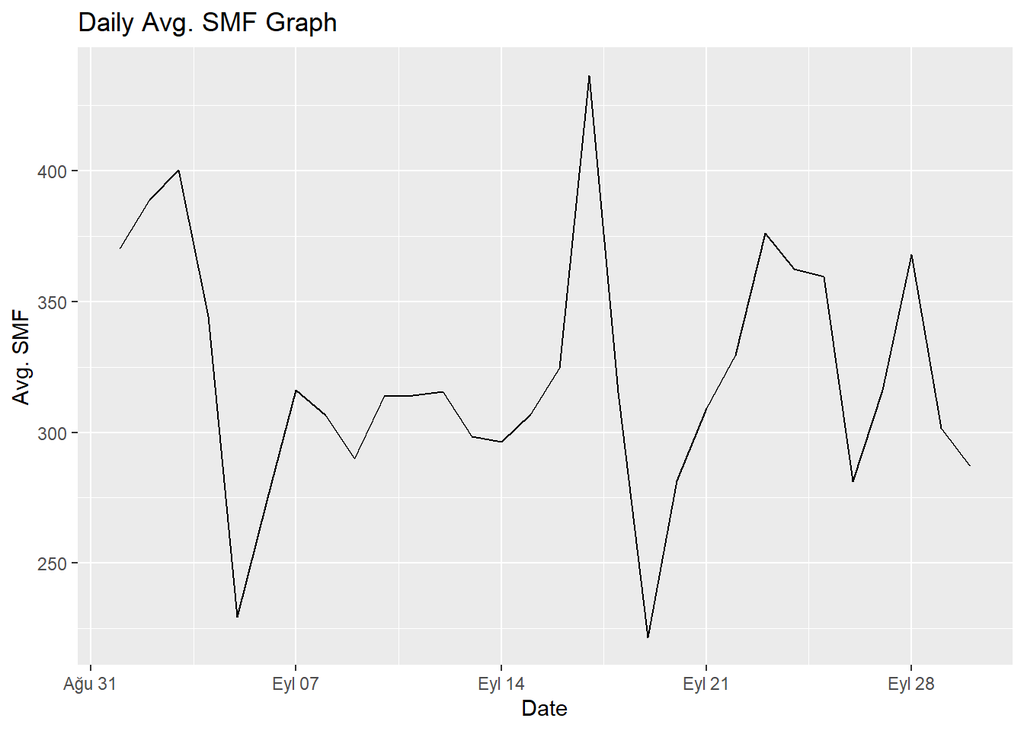

```r
ggplot(Electricity_Data_Daily2, aes(x=date, y=avg_SMF))+
  geom_line()+
  labs(title="Daily Avg. SMF Graph",x ="Date", y = "Avg. SMF")
```

This graph is showing us the daily average PTF value change over time.

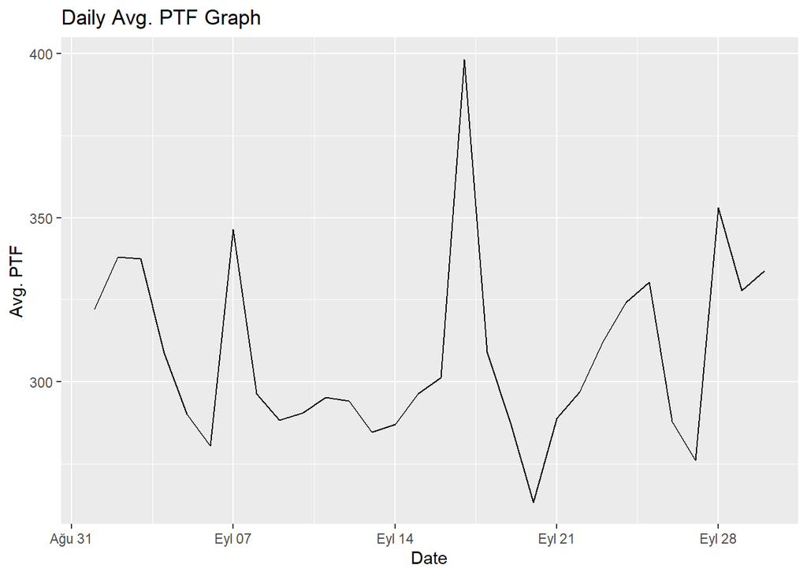

```r
ggplot(Electricity_Data_Daily2, aes(x=date, y=avg_PTF))+
  geom_line()+
  labs(title="Daily Avg. PTF Graph",x ="Date", y = "Avg. PTF")
```

### Analyzing daily values grouped by `SMF.Yön`

Daily values grouped by `SMF.Yön`and date.

```r
Electricity_Data_Daily <- Electricity_Data_Adjusted %>%
  group_by(date = lubridate::date(Tarih), SMF.Yön) %>%
  summarize(tot_SMF = sum(SMF), tot_PTF = sum(PTF), tot_PozDenge = sum(poz_deng_fiyat), tot_NegDenge = sum(neg_den_fiyat),
            avg_SMF = mean(SMF), avg_PTF = mean(PTF))
```

Bar plot of Energy Status on a daily basis to see their frequencies in September.

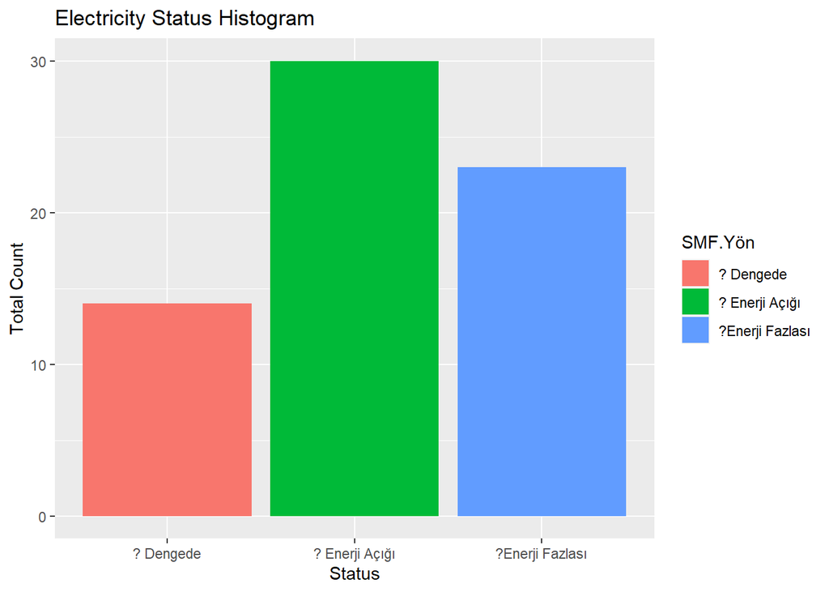

```r
ggplot(Electricity_Data_Daily, aes(x=SMF.Yön, fill=SMF.Yön))+
  geom_histogram(stat = "count")+
  labs(title="Electricity Status Histogram",x ="Status", y = "Total Count")
```

### Examining the dataset hourly basis

Examining the data set hourly basis:

```r
Electricity_Data_Hourly <- Electricity_Data_Adjusted %>%
  group_by(hour = lubridate::hour(Tarih)) %>%
  summarize(tot_SMF = sum(SMF, na.rm=T), tot_PTF = sum(PTF), tot_PozDenge = sum(poz_deng_fiyat), tot_NegDenge = sum(neg_den_fiyat),
            avg_SMF = mean(SMF, na.rm=T), avg_PTF = mean(PTF))
```

### Hourly key metrics’ visualization

This graph is showing us the hourly average SMF value change over time.

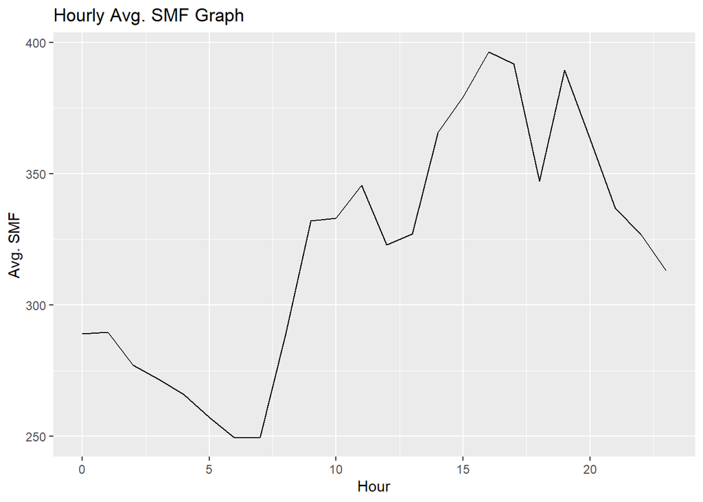

```r
ggplot(Electricity_Data_Hourly, aes(x=hour, y=avg_SMF))+
  geom_line()+
  labs(title="Hourly Avg. SMF Graph",x ="Hour", y = "Avg. SMF")
```

This graph is showing us the hourly average PTF value change over time.

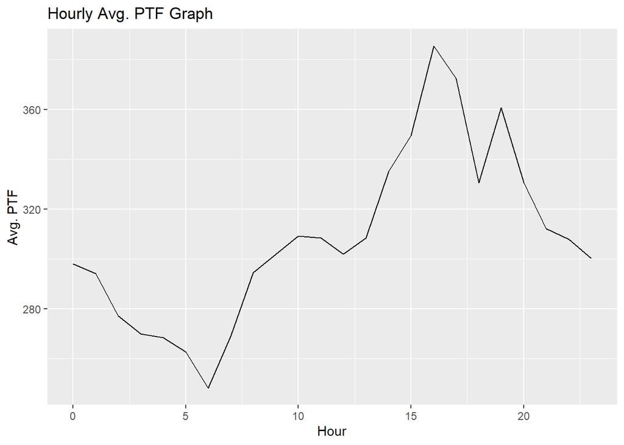

```r
ggplot(Electricity_Data_Hourly, aes(x=hour, y=avg_PTF))+
  geom_line()+
  labs(title="Hourly Avg. PTF Graph",x ="Hour", y = "Avg. PTF")
```

This graph shows us comparison between hourly avg. SMF and hourly avg. PTF in a scatter plot:

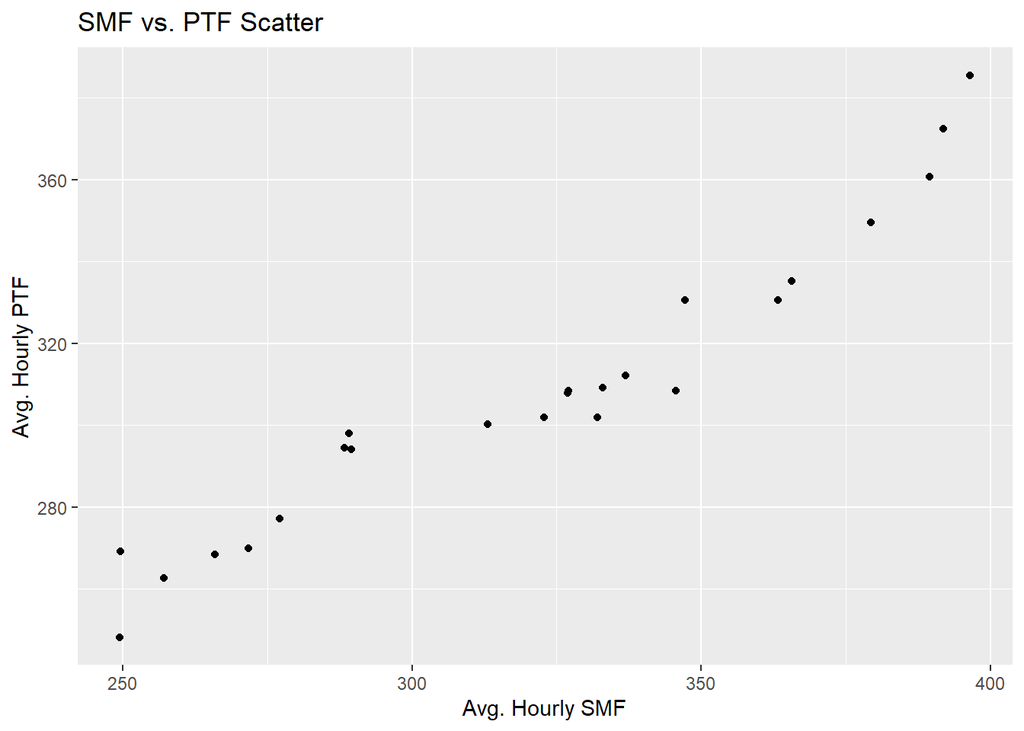

```r
ggplot(Electricity_Data_Hourly, aes(x=avg_SMF, y=avg_PTF))+
  geom_point()+
  labs(title="SMF vs. PTF Scatter",x ="Avg. Hourly SMF", y = "Avg. Hourly PTF")
```